# APEX active layer analysis

Manies

2022-03-23

Needed libraries:

```r
library(lubridate)
library(ggplot2)
library(dplyr)   #left_join
```

## Importation of data files

The data included in this analysis are from various sources. All data are originally from Excel files where a tab was saved in csv format.  
Once imported each file needed their time stamp converted into strptime.

```r
guelph <- read.csv("raw_data/Seasonal Thaw Depth Data Dielman.csv",header=TRUE)
usgs1 <- read.csv("raw_data/FINAL End of Season usgs.csv",header=TRUE)
crell <- read.csv("raw_data/douglas APEX ERT lines thaw depths October 2017.csv", header=TRUE)
```

Add a column to each dataset so we know where the data is from.

```r
usgs1 <- cbind(usgs1, source="USGS")
guelph <- cbind(guelph, source="Guelph")
crell <- cbind(crell, source="CRELL")
```

## Basic review of each dataset by plotting data

### Guelph data from Katherine Dielman:

Measurements with permafrost are called “Permafrost Plateau” under Site.  
Names changed throughout the study time. Here old names are converted to current names.

```r
lookup <- read.csv("raw_data/guelph_lookup.csv",header=TRUE)
lookup$Plot <- as.character(lookup$Plot)
guelph <- left_join(guelph, lookup, by = c("Treatment" , "Plot"))
guelph$new_plot2 <- ifelse(is.na(guelph$new_plot),guelph$Plot,guelph$new_plot)

guelph.gamma <- subset(guelph, Site=="Permafrost Plateau ")
guelph.gamma$Date <- strptime(guelph.gamma$Date, format="%m/%d/%Y", tz="America/Anchorage")
guelph.gamma$month <- month(guelph.gamma$Date)
guelph.gamma.AugOn <- subset(guelph.gamma, month=="8" | month=="9" | month=="10")
aggregate(Ice_Depth_cm ~ Year, guelph.gamma.AugOn, mean)
```

```
##   Year Ice_Depth_cm
## 1 2008     33.05000
## 2 2009     37.76111
## 3 2010     44.29756
## 4 2011     44.05278
## 5 2012     49.00000
## 6 2017     59.98052
## 7 2018     72.35000
## 8 2019     72.60000
```

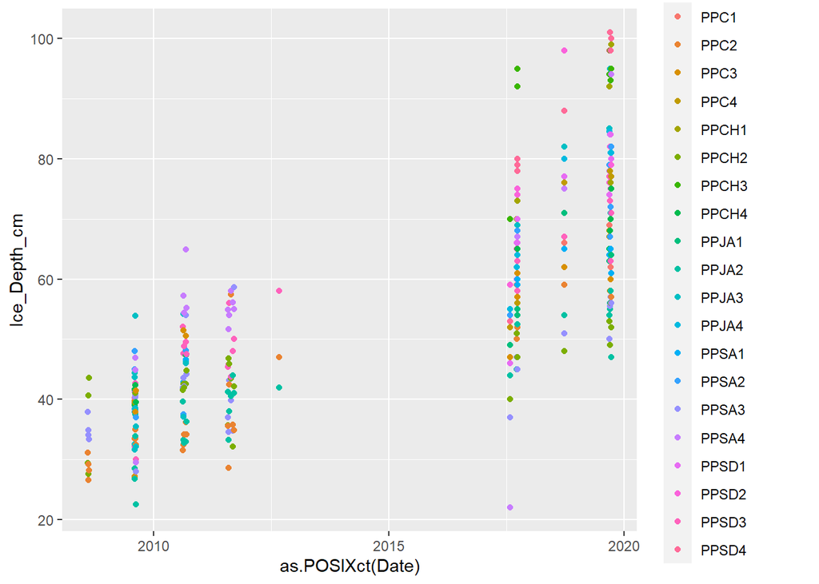

```r
g.gamma.AugOn.plot <- ggplot() +
  geom_point(data=guelph.gamma.AugOn, aes(x=as.POSIXct(Date), y=Ice_Depth_cm, color=factor(new_plot2)))
print(g.gamma.AugOn.plot)
```

QUESTION: How do these sites relate to each other spatially?

### USGS

Measurements with permafrost are labeled “forest” under Treatment Need to convert the date column from a character to a date

```r
usgs.gamma <- subset(usgs1, usgs1$Treatment == "forest")
usgs.gamma$date <- strptime(usgs.gamma$date, format="%d-%b-%y", tz="America/Anchorage")
usgs.gamma.AugOn <- subset(usgs.gamma, format(usgs.gamma$date,"%b")=="Aug" | format(usgs.gamma$date,"%b")=="Sept")
aggregate(AL_cm ~ year, usgs.gamma.AugOn, mean)
```

```
##   year    AL_cm
## 1 2013 49.48077
## 2 2014 49.08333
## 3 2015 46.00000
```

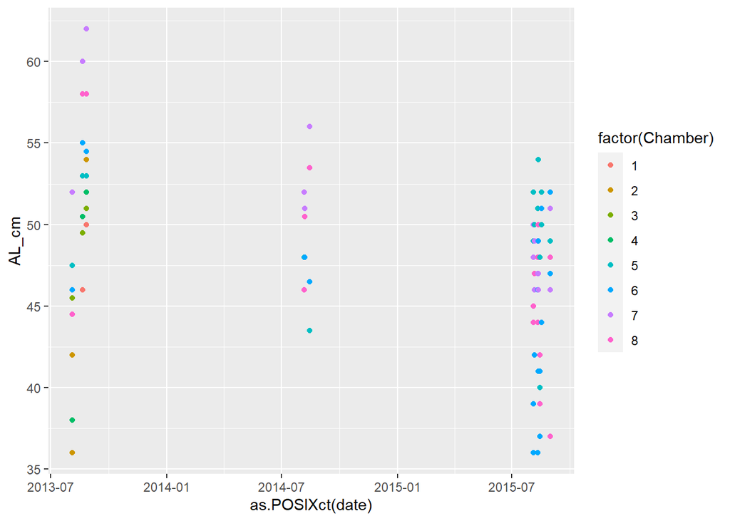

```r
usgs.gamma.Augon.plot <- ggplot(usgs.gamma.AugOn, aes(x=as.POSIXct(date), y=AL_cm)) +
  geom_point(aes(color=factor(Chamber)))
print(usgs.gamma.Augon.plot)
```

USGS data only until 2015. We must have more active layer measurements (associate with the BZPC cores) that we can include.

### CRELL data from Tom Douglas

Type of site was assigned by Kristen Manies based on the descriptions. Anything that said it had live spruce was assumed to have permafrost. Anything labeled thermokarst, noted to have standing water, or dead spruce was assumed to be thawed. For the few rows without descriptions the determination was based on adjacent rows and/or the depth measurements.

```r
crell.gamma <- subset(crell, Site=="Pfrost")
#extract date from timestamp
crell.gamma$date <-substr(crell.gamma$DateTime, 1, 10)
crell.gamma$transect <- substr(crell.gamma$Name, 4,5)
crell.gamma$year <- year(crell.gamma$date)
aggregate(Depth ~ transect, crell.gamma, mean)
```

```
##   transect    Depth
## 1       T3 66.75000
## 2       T4 75.56667
## 3       T7 58.91667
```

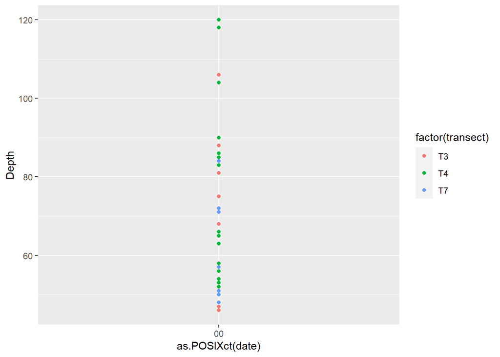

```r
crell.gamma$date <- as.POSIXct(crell.gamma$date, "%Y-%m-%d", tz="America/Anchorage")
crell.gamma.plot <- ggplot(crell.gamma, aes(x=as.POSIXct(date), y=Depth)) +
  geom_point(aes(color=factor(transect)))
print(crell.gamma.plot)
```

## Combining all datasets

Combine gamma data from all three data sets and plot over time. Columns in new dataframe will be: site (aka within gamma location), Date (%Y-%m-%d format), and active layer depth

```r
cg.sub <- data.frame(crell.gamma$transect, crell.gamma$date, crell.gamma$Depth, crell.gamma$source)
gg.sub <- data.frame(guelph.gamma$Treatment, guelph.gamma$Date, guelph.gamma$Ice_Depth_cm, guelph.gamma$source)
usgs.sub <- data.frame(usgs.gamma$Chamber, usgs.gamma$date, usgs.gamma$AL_cm, usgs.gamma$source)
same.names <- function(df) {
  names(df)[1] <- "location"
  names(df)[2] <- "date"
  names(df)[3] <- "depth"
  names(df)[4] <- "source"
  return(df)
}
cg.sub <-same.names(cg.sub)
gg.sub <-same.names(gg.sub)
usgs.sub <- same.names(usgs.sub)
all.gamma <- rbind(cg.sub, gg.sub, usgs.sub)
```

Plot the data

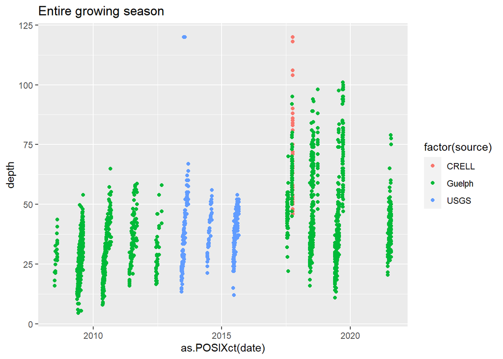

```r
all.plot <- ggplot(data=all.gamma, aes(x=as.POSIXct(date), y=depth)) +
  geom_point(aes(color=factor(source))) +
  ggtitle("Entire growing season")
print(all.plot)
```

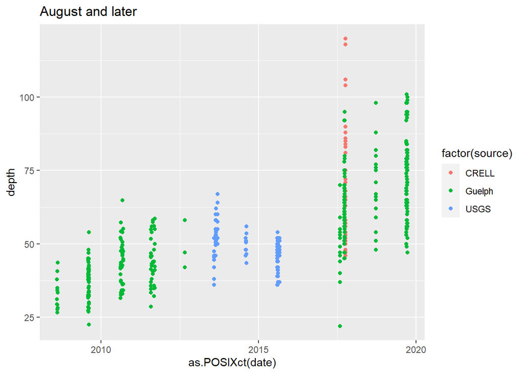

```r
august.on <- subset(all.gamma, month(date)>=8)
aug.plot <- ggplot(data=august.on, aes(x=as.POSIXct(date), y=depth)) +
  geom_point(aes(color=factor(source))) +
  ggtitle("August and later")
print(aug.plot)
```